# FinalProject

Hao Jyun Bai

2024-03-18

Abstract:

The purpose of this project is to use neural activity data and stimuli information to predict trial outcomes. To effectively manage the complexity of the data and optimize model performance, I first explored the dataset and made some interesting findings. I decided to focus mainly on neuron activity between trials and sessions, and also to examine the success rate by feedback type for the final model. Second, I applied PCA to standardize and reduce the complexity of the final model and generated several graphs to visualize the PCA results. Lastly, I built four different models using logistic regression, random forest, SVM, and XGBoost to test on the AUC and compared their performance on this test data.

Section 1:Introduction

To explore data and begin the analysis, we first need to load the data into our environment.

load data:

```r
session=list()
for(i in 1:18){
  session[[i]]=readRDS(paste('C:/STA141/sessions/session',i,'.rds',sep=''))
#print(session[[i]]$mouse_name)
#print(session[[i]]$date_exp)

}
```

Introduction to data:

We have a total 18 sessions with different length of trials. Each session represents a unique set of trials, included contrasts of visual cues on the left and right for specific stimuli to the mice, the brain area by the number of neurons monitored, and the feedback type indicating the outcome of each trial is success or not by positive (1) as success and negative (-1) as failure.

```
## Session 1
## Number of trials: 114
## Number of neurons (first trial): 734
## Stimuli conditions (first trial): Left 0 Right 0.5
## Brain area (first trial): ACA
## Feedback type (first trial): 1
##
## Session 2
## Number of trials: 251
## Number of neurons (first trial): 1070
## Stimuli conditions (first trial): Left 1 Right 1
## Brain area (first trial): CA1
## Feedback type (first trial): -1
##
## Session 3
## Number of trials: 228
## Number of neurons (first trial): 619
## Stimuli conditions (first trial): Left 0.5 Right 0
## Brain area (first trial): DG
## Feedback type (first trial): 1
##
## Session 4
## Number of trials: 249
## Number of neurons (first trial): 1769
## Stimuli conditions (first trial): Left 0 Right 1
## Brain area (first trial): LGd
## Feedback type (first trial): 1
##
## Session 5
## Number of trials: 254
## Number of neurons (first trial): 1077
## Stimuli conditions (first trial): Left 0 Right 1
## Brain area (first trial): VISa
## Feedback type (first trial): 1
##
## Session 6
## Number of trials: 290
## Number of neurons (first trial): 1169
## Stimuli conditions (first trial): Left 0.25 Right 0
## Brain area (first trial): AUD
```

[output cut: 70 more lines]

```
## Feedback type (first trial): 1
##
## Session 17
## Number of trials: 224
## Number of neurons (first trial): 565
## Stimuli conditions (first trial): Left 0 Right 0
## Brain area (first trial): root
## Feedback type (first trial): -1
##
## Session 18
## Number of trials: 216
## Number of neurons (first trial): 1090
## Stimuli conditions (first trial): Left 0.5 Right 0
## Brain area (first trial): CP
## Feedback type (first trial): 1
```

Engaging data with initialize three parameters, then using for-loop to iterate every unique sessions for a total 18. Then, output number of trial in each session, number of average neurons in each session and a list contains a vector with the mean contrast levels for left and right stimuli for that session.

```
##  [1] 114 251 228 249 254 290 252 250 372 447 342 340 300 268 404 280 224 216
```

```
##  [1]  734 1070  619 1769 1077 1169  584 1157  788 1172  857  698  983  756  743
## [16]  474  565 1090
```

```
## [[1]]
## [1] 0.2960526 0.4298246
##
## [[2]]
## [1] 0.3177291 0.3515936
##
## [[3]]
## [1] 0.2357456 0.3684211
##
## [[4]]
## [1] 0.3343373 0.3222892
##
## [[5]]
## [1] 0.3385827 0.3562992
##
## [[6]]
## [1] 0.3534483 0.3250000
##
## [[7]]
## [1] 0.2936508 0.3253968
##
## [[8]]
## [1] 0.442 0.375
##
## [[9]]
## [1] 0.4065860 0.2674731
##
## [[10]]
## [1] 0.3847875 0.2701342
##
## [[11]]
## [1] 0.3347953 0.3135965
##
## [[12]]
## [1] 0.2889706 0.3250000
##
## [[13]]
## [1] 0.3558333 0.3050000
##
## [[14]]
## [1] 0.3320896 0.3059701
##
## [[15]]
## [1] 0.3391089 0.3347772
##
## [[16]]
## [1] 0.3678571 0.3071429
##
## [[17]]
## [1] 0.3247768 0.3872768
##
## [[18]]
## [1] 0.3194444 0.3032407
```

At the end of section 1, print it as a table to help us visualize the entire dataset easier and cleaner. This also shows information about what a single session has.

```
##    Session NumTrials AvgNeurons AvgContrastLeft AvgContrastRight MouseName
## 1        1       114        734       0.2960526        0.4298246      Cori
## 2        2       251       1070       0.3177291        0.3515936      Cori
## 3        3       228        619       0.2357456        0.3684211      Cori
## 4        4       249       1769       0.3343373        0.3222892 Forssmann
## 5        5       254       1077       0.3385827        0.3562992 Forssmann
## 6        6       290       1169       0.3534483        0.3250000 Forssmann
## 7        7       252        584       0.2936508        0.3253968 Forssmann
## 8        8       250       1157       0.4420000        0.3750000     Hench
## 9        9       372        788       0.4065860        0.2674731     Hench
## 10      10       447       1172       0.3847875        0.2701342     Hench
## 11      11       342        857       0.3347953        0.3135965     Hench
## 12      12       340        698       0.2889706        0.3250000 Lederberg
## 13      13       300        983       0.3558333        0.3050000 Lederberg
## 14      14       268        756       0.3320896        0.3059701 Lederberg
```

[output cut: 23 more lines]

Section 2:Exploratory analysis

Visualize neural activity with specific session and specific trial

Exploring the data step-by-step, I decided to focus on one specific session and one specific trial first to experiment with the visualization. At this point, the graph only shows partial correlation between firing rate (spike rate) and neuron activity; therefore, it’s not advisable to stop here. I decided to proceed by looking at the average across all trials.

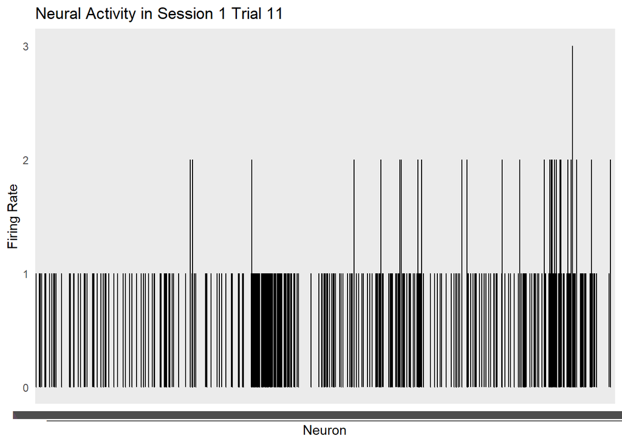

Visualize neural activity with specific session and all trials

In this graph, each bar corresponds to a different neuron, compared to the first graph it makes more sense. Most of the neurons activity remains low firing rate, but some of them display more variability and active at some points, observing these special point might give us some significant feedback.I would try to do different approach next to see if the assumtion is right.

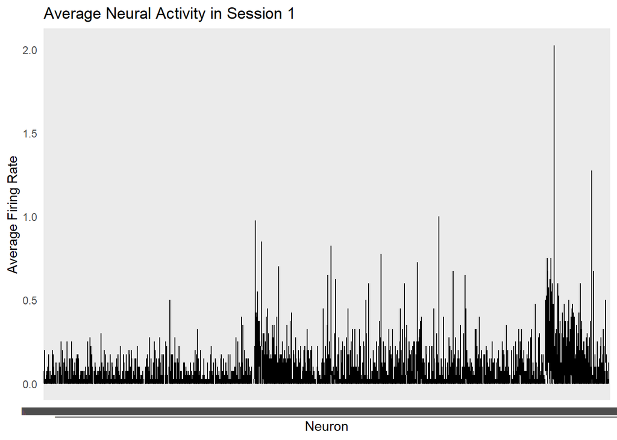

Visualize neural activity with specific session and all trial in other approach

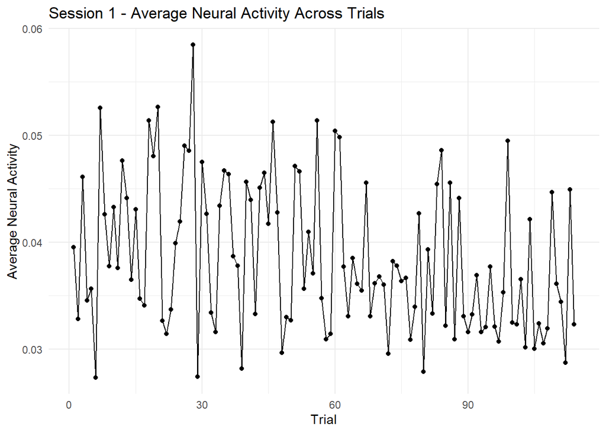

Visualize neural activity with specific session with 5 different trials

Last with neural activity, compared exactly 5 different trials to implement the consistency mentioned in last graph. As they graph shows, all the graphs seems to have similar pattern and show consistency. This prove the assumption we made earlier is right and make sure majority of neurons in different trials are low.

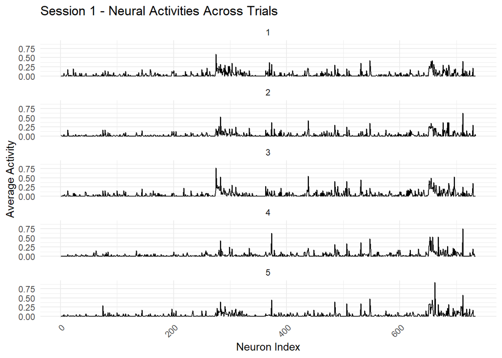

Visualize neural activity by brain area across sessions

From this graph, we could make assumption for two: First, although there is variability, some brain areas represent a relatively consistent level of activity across different sessions. Second, session to session might have variability for brain area as well.We could check on those relatively high bar in the chart to analyze different brain areas activity.

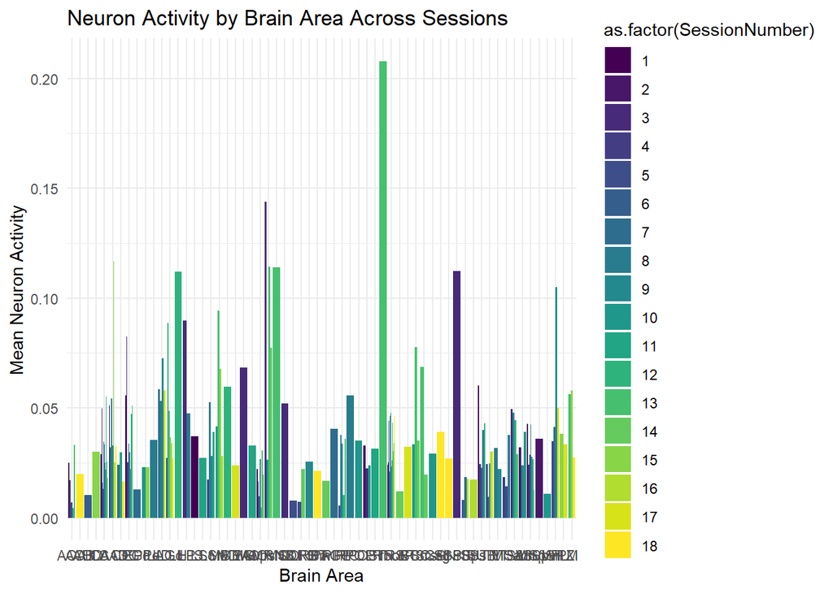

Calculate correlation result(success rate) by feedback_type

To analyze the correlation result(success rate) with chart, first we need to setup the correlation result by number,using binary vectors to determine the success rate by looking at the feedback_type equal to one, instead of one would determine as failure.Finally, by Calculates the Spearman’s rank correlation between the average firing rates and the trial success vector and stores the result in the corresponding index

```
## Correlation results per session:
```

```
##  [1] 0.38502557 0.20608632 0.27082190 0.12474594 0.31900519 0.07116390
##  [7] 0.16638428 0.29512296 0.29142332 0.18302722 0.24022281 0.26766493
## [13] 0.13924315 0.25920263 0.22263189 0.23926985 0.08222713 0.20964998
```

Visualize correlation result(success rate) by feedback_type

Lastly on the section 2, we have the visualization of correlation result, with trial outcomes based on the feedback type.The absence of significant outliers or extreme variations indicates that the firing rates remain relatively uniform across various trials and outcomes.Also, there are some sessions looks special then other sessions(example:6,11), focusing on these might found more variation between each sessions.

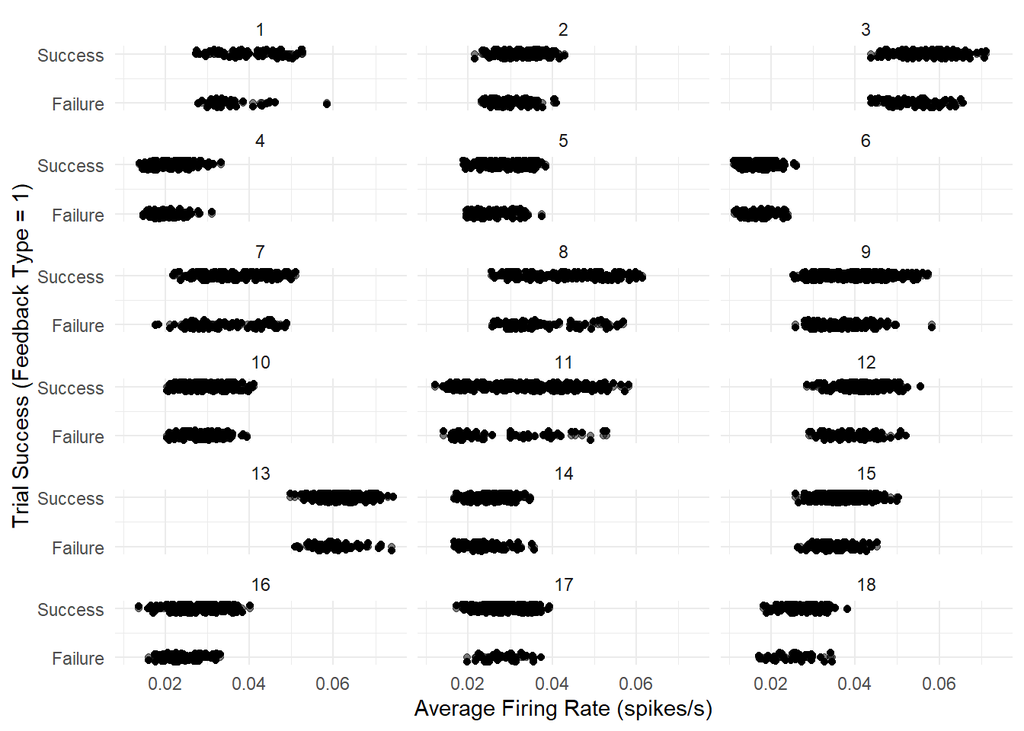

Section 3:Data integration

For data integration, first we have to setup the average firing rate fir each neuron per session:

Apply PCA as Data integration

I choose PCA to do dimensionality reduction for our data, which gave us ability to not lose too much datas and analyze variation with straight direction. Apply PCA as data integration for flatten the spike data, which would print us standard deviation, proportion of variance and cumulative proportion.

```
## Importance of components:
##                           PC1     PC2    PC3     PC4     PC5     PC6     PC7
## Standard deviation     5.1665 1.59952 1.0565 0.85410 0.82827 0.72151 0.66553
## Proportion of Variance 0.6673 0.06396 0.0279 0.01824 0.01715 0.01301 0.01107
## Cumulative Proportion  0.6673 0.73127 0.7592 0.77741 0.79456 0.80757 0.81865
##                            PC8     PC9    PC10    PC11    PC12    PC13    PC14
## Standard deviation     0.63008 0.60244 0.56863 0.54071 0.52717 0.50746 0.49646
## Proportion of Variance 0.00993 0.00907 0.00808 0.00731 0.00695 0.00644 0.00616
## Cumulative Proportion  0.82857 0.83765 0.84573 0.85304 0.85999 0.86642 0.87259
##                           PC15    PC16    PC17    PC18    PC19    PC20    PC21
## Standard deviation     0.48901 0.47584 0.47388 0.46928 0.46603 0.46165 0.45882
## Proportion of Variance 0.00598 0.00566 0.00561 0.00551 0.00543 0.00533 0.00526
## Cumulative Proportion  0.87857 0.88423 0.88984 0.89535 0.90077 0.90610 0.91137
##                           PC22    PC23    PC24    PC25    PC26   PC27    PC28
## Standard deviation     0.45634 0.45259 0.45101 0.44653 0.44393 0.4429 0.44184
## Proportion of Variance 0.00521 0.00512 0.00509 0.00498 0.00493 0.0049 0.00488
## Cumulative Proportion  0.91657 0.92169 0.92678 0.93176 0.93669 0.9416 0.94648
##                           PC29    PC30    PC31    PC32    PC33   PC34    PC35
## Standard deviation     0.43877 0.43515 0.43129 0.42855 0.42708 0.4245 0.42201
## Proportion of Variance 0.00481 0.00473 0.00465 0.00459 0.00456 0.0045 0.00445
## Cumulative Proportion  0.95129 0.95602 0.96067 0.96526 0.96982 0.9743 0.97878
##                           PC36    PC37    PC38    PC39    PC40
## Standard deviation     0.41917 0.41860 0.41024 0.40738 0.40450
## Proportion of Variance 0.00439 0.00438 0.00421 0.00415 0.00409
## Cumulative Proportion  0.98317 0.98755 0.99176 0.99591 1.00000
```

Length matching for PCA

Matching length for each trail and session to update the index. Then we could generate plot with this PCA data.

```
## [1] TRUE
```

```
## [1] TRUE
```

PCA graph analysis(session)

According to the PCA graph, there is a session overlap, which means different session might not have too much different,in other words, has similar structure.Very little outlier also indicated about the consistency in the neural data across trials.

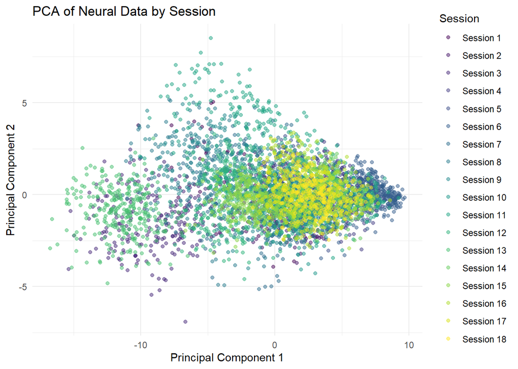

PCA graph analysis(Mouse Name)

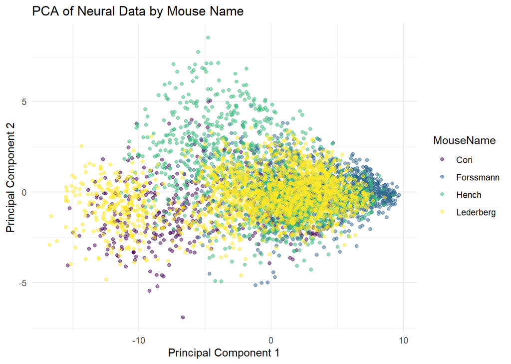

PCA graph analysis(clustered)

By clustering, now we have three different type of pattern, The concentration of data points in Cluster 1 (red) appears sparser compared to Cluster 3 (blue), suggesting a greater diversity in the features represented by Cluster 1.

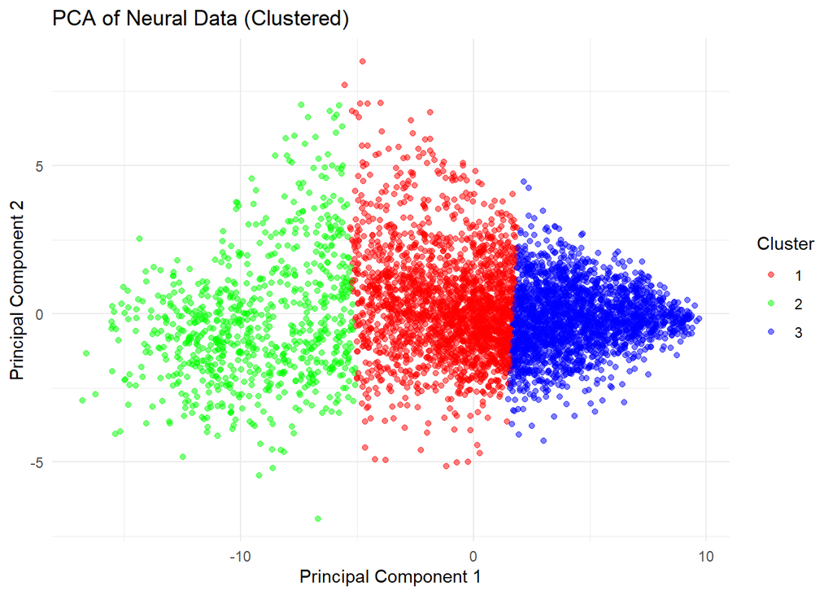

Section 4:Predictive modeling

```
## 'data.frame':    1000 obs. of  6 variables:
##  $ X1           : num  1.371 -0.565 0.363 0.633 0.404 ...
##  $ X2           : num  2.325 0.524 0.971 0.377 -0.996 ...
##  $ X3           : num  0.251 -0.278 -1.725 -2.007 -1.292 ...
##  $ X4           : num  -0.686 -0.793 -0.407 -1.149 1.116 ...
##  $ X5           : num  -0.142 -0.814 -0.326 0.378 -1.994 ...
##  $ feedback_type: int  0 1 0 1 1 1 1 1 1 0 ...
```

logistic regression model

Model building:

```
##
## predicted_classes  0  1
##                 0 52 45
##                 1 50 53
```

```
## [1] "Accuracy: 0.525"
```

Confusion matrix:

Might be the worst model out of four since the confusion matrix has relatively low true negatives and true positive.

[figure not shown]

random forest model

Model building:

```
## Confusion Matrix and Statistics
##
##           Reference
## Prediction  0  1
##          0 43 42
##          1 59 56
##
##                Accuracy : 0.495
##                  95% CI : (0.4237, 0.5664)
##     No Information Rate : 0.51
##     P-Value [Acc > NIR] : 0.6898
##
##                   Kappa : -0.007
##
##  Mcnemar's Test P-Value : 0.1114
##
##             Sensitivity : 0.4216
##             Specificity : 0.5714
##          Pos Pred Value : 0.5059
##          Neg Pred Value : 0.4870
##              Prevalence : 0.5100
##          Detection Rate : 0.2150
##    Detection Prevalence : 0.4250
##       Balanced Accuracy : 0.4965
##
##        'Positive' Class : 0
##
```

Confusion matrix:

[figure not shown]

SVM model

Model building:

```
##   0   1
## 118  82
```

Confusion matrix:

Average performance with confusion matrix, although true positive is relatively high, true negatives is relatively low.

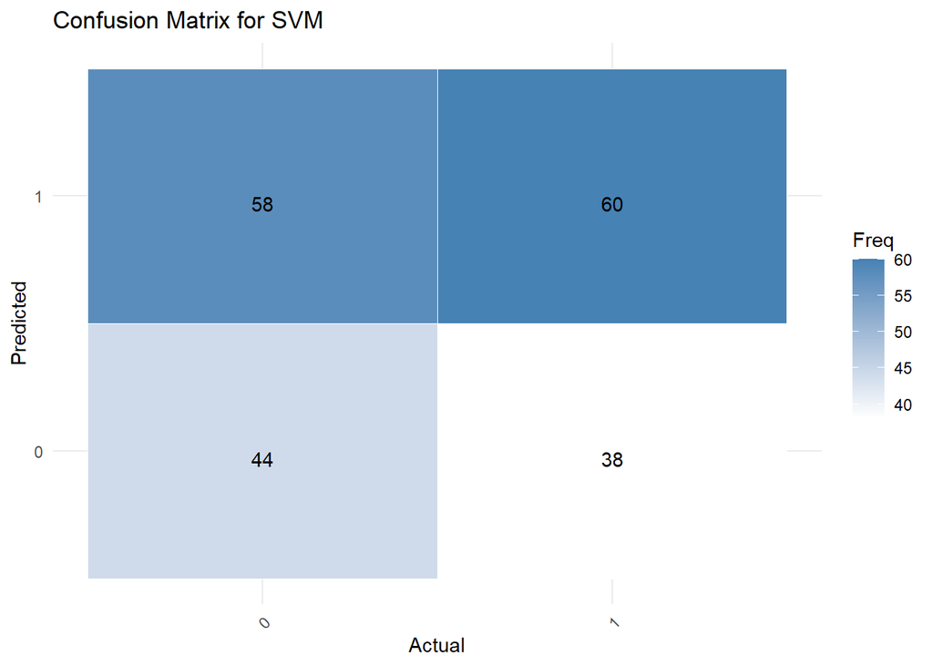

XGboost model

Model building:

[output not shown]

Confusion matrix:

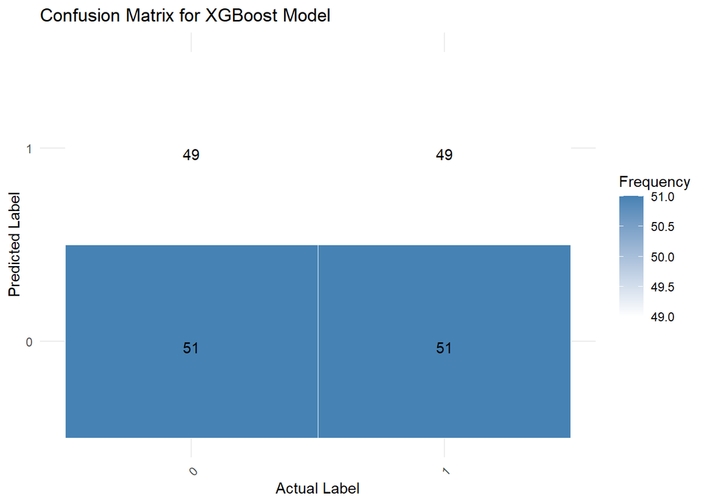

Evalute 4 models AUC with ROC graph

According to the graph, although they all have similar performance, random forest and SVM shows relatively high performance out of 4 models.

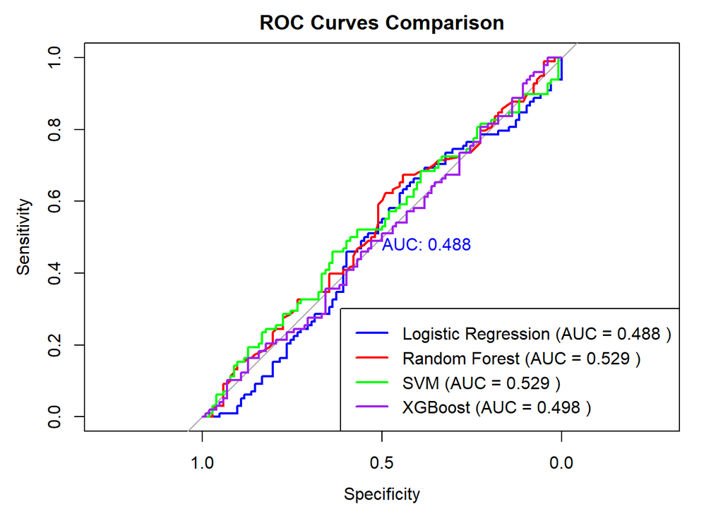

Section 5:Prediction performance on the test sets

Test data 1

Test data 1 with logistic regression

model building:

```
##          Actual
## Predicted   0   1
##         0 243 263
##         1 250 244
```

```
## [1] "Accuracy for test1: 0.487"
```

Confusion matrix:

It perform even worse than section 4, which only has 48.7% accuracy.

[figure not shown]

random forest model(test data 1)

model building & Confusion matrix:

Relatively better than logistic regression with decent amonut of true positve.

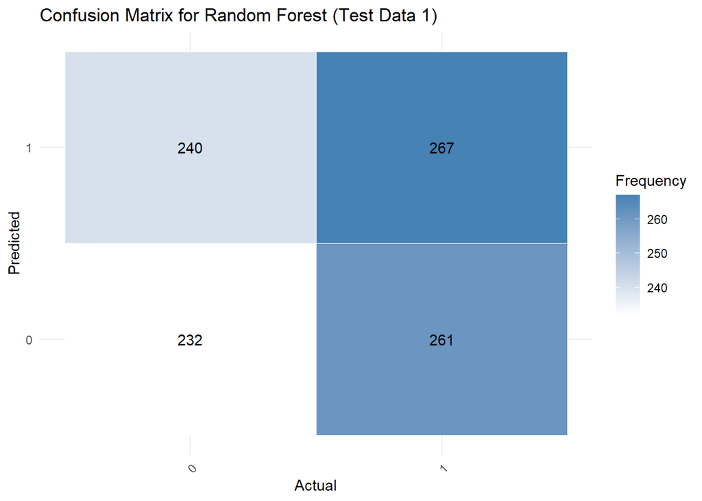

SVM model(test data 1)

model building & Confusion matrix:

Seems slightly better than random forest method since it has more true positve. but Meanwhile it has low true negative.

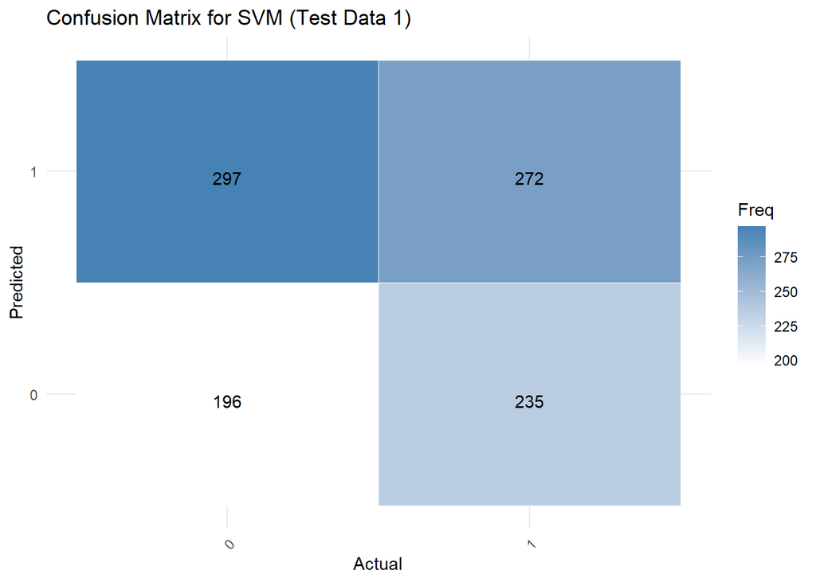

XGboost model(test data 1)

model building & Confusion matrix:

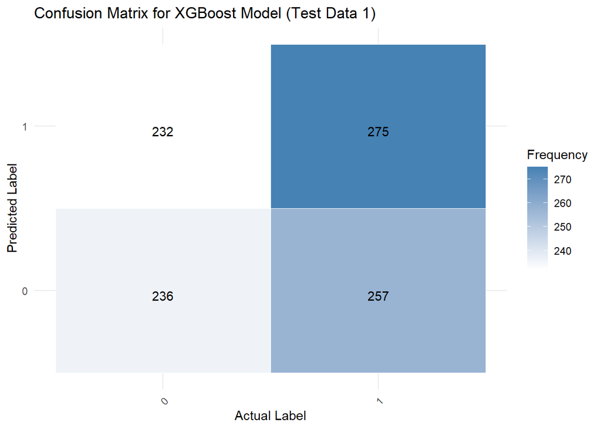

ROC graphs for test data 1

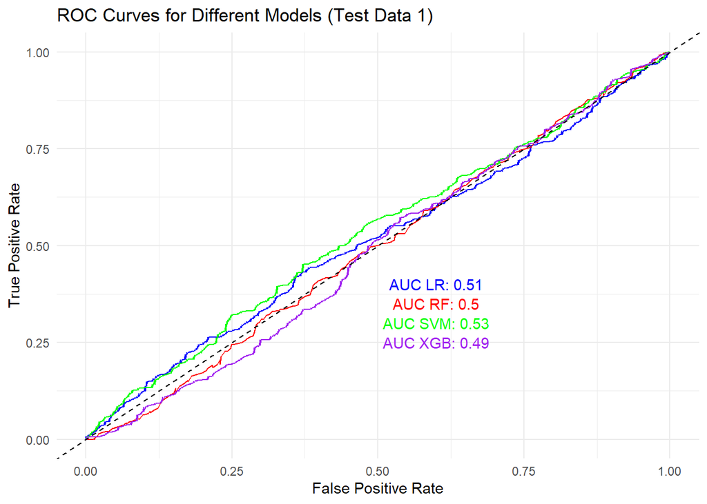

Test data 2

load data:

logistic regression(test data 2)

model building:

```
##          Actual
## Predicted   0   1
##         0 279 227
##         1 246 248
```

```
## [1] "Accuracy for test2: 0.527"
```

Confusion matrix:

[figure not shown]

random forest model(test data 2)

Model building $ Confusion matrix:

It shows average peformance since the true positive and true negative are relatively high.

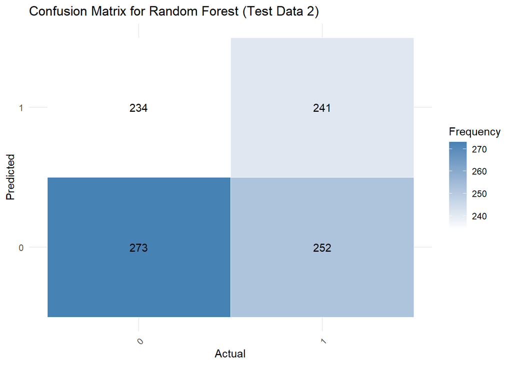

SVM model(test data 2)

Model building $ Confusion matrix:

Very high true positive but relatively low true negative.

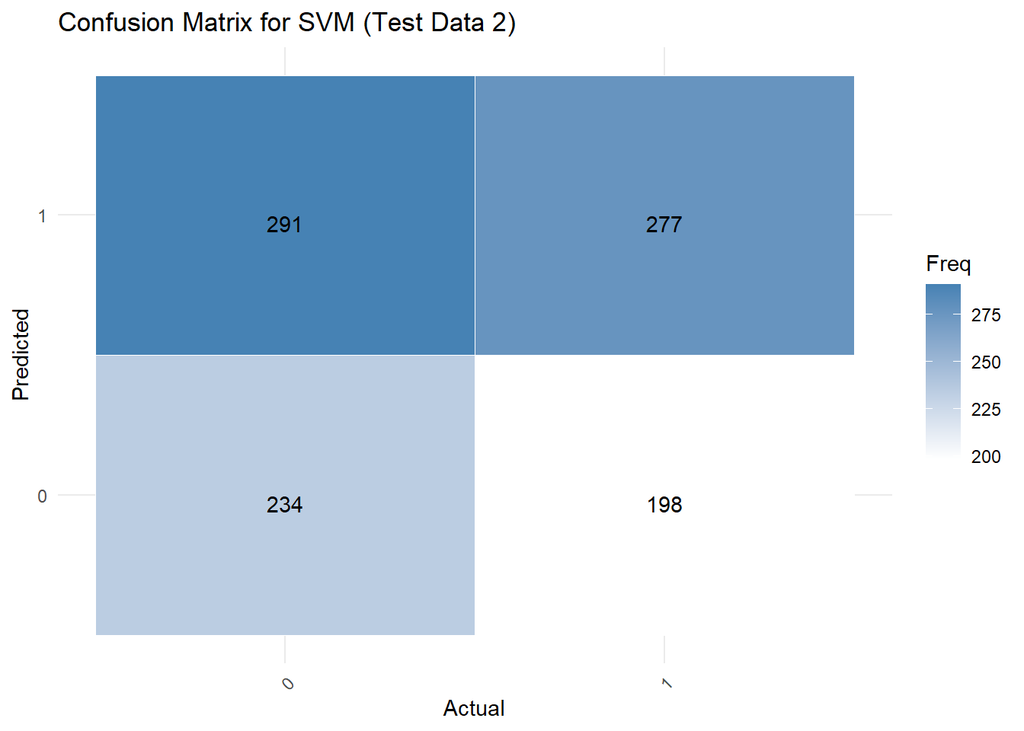

XGboost model(test data 2)

Model building $ Confusion matrix:

Relatively low true positive and true negative compared to other models.

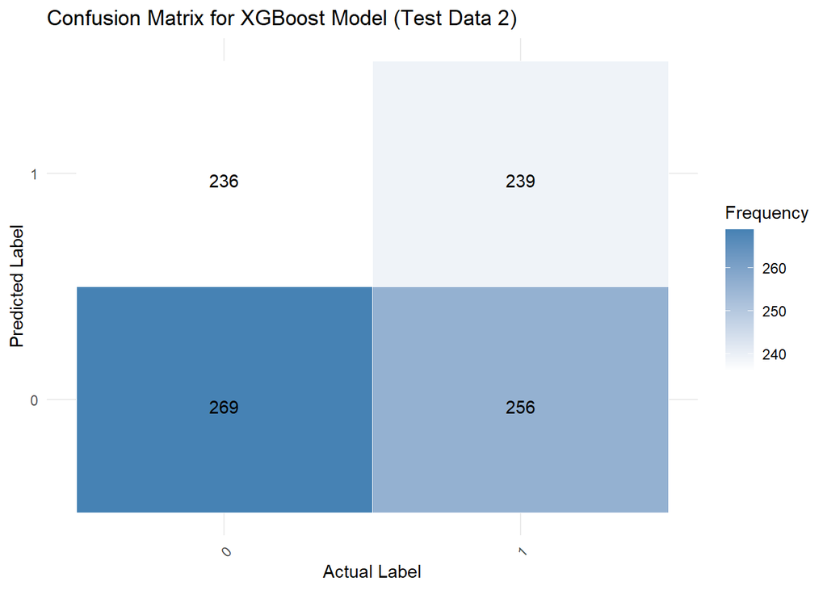

ROC graphs for test data 2

Similar in test data 1, they all have similar performance, but in this case 4 of the model performance are really close with 0.02 different.

[figure not shown]

Section 6:Discussion

2.Focusing on 2 specific model: I have tried too much method to compare AUC leads to less precise on every of them, I would considered to reduce method and mainly focus on random forest and XGB, which are two method I have relatively high accuracy overall.

3.PCA implementaion: Even apply PCA in, model still has relatively poor performance, I guess revise the way I tried PCA might be a good start to improve my model. I believe apply PCA in the more proper way should raise AUC over 70%.

Reference

Steinmetz, N.A., Zatka-Haas, P., Carandini, M. et al. Distributed coding of choice, action and engagement across the mouse brain. Nature 576, 266–273 (2019). https://doi.org/10.1038/s41586-019-1787-x

ChatGPT - Assist with apply PCA, model building, confusion matrix and data explore.(whole chat logs on github)

Jue Wang - Course_project_demo.html